# Doctor Who - Revamped

Author: Michał Bryzik

Date: 4/25/2024

*Doctor Who* is a long-running **British** sci-fi series following the adventures of the Doctor, a Time Lord who travels through time and space in a ship disguised as a police box, known as the **TARDIS**.

[figure not shown]

## Plot of the Series

Doctor as previously described is a *timeless* identity [precisely had 13 lives but won't spoil anymore] is a representant of the Time Lords species. People that could seemlessly travel through time and space. Along his journey with his companions, he fight villains and saves lives.

## Average Rating: 84

Data for the whole below analysis can be found on [kaggle](https://www.kaggle.com/datasets/jacklacey/doctor-who-episodes-20052021).

As we are looking specifically at only the revamped series [*from 2005 and our dataset ends at 2021*]. I will be looking at comparison between specific **doctors** [different actors], **seasons** and **directors** in order to say, which were the most loved and most liked episodes of the community.

#### Show Statistics:

- Average Viewers: **7.5 mln**

- Average Score: **84**

- Most Beloved Episode: **The Stolen Earth**

- Least Liked Episode: **Once, Upon Time**

- Most Beloved Doctor: **David Tennant**

- Least Beloved Doctor: **Jodie Whittaker**

#### Viewership over Time

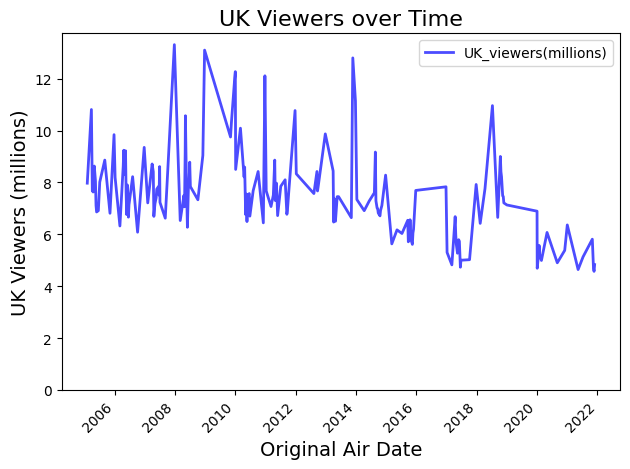

#### Appreciation over Time

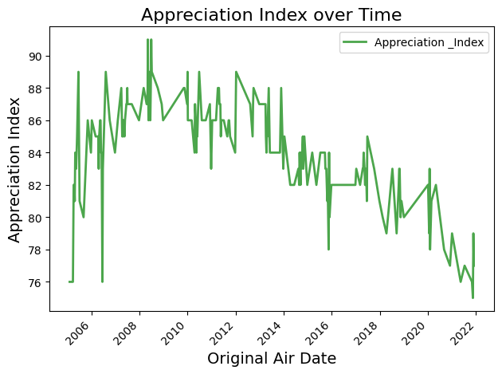

As we can see the overall popularity of the show is decreasing, from around **11 mln** viewers at 2010 to around **6 mln** viewers at 2020. Additionally rating tho stays at a relatively high level is also decreasing. Obviously a big part of that could be a raise in popularity of **streaming platforms** and increase in number of overall productions.